# Machine Learning with `R`

# Univariate Descriptions

# Introduction

Univariate analysis is the simplest one. Despite the fact that a plethora of tools has been developed for this aim, these are usually not very sophisticated. The tools here presented probably are the most known and used too. Anyway, some introduction to them may be useful.

# Numerical Analysis

To illustrate some examples of descriptions, the `wea` data frame will be used first (see the section *Introduction and datasets used* for further information).

The simplest text-based statistical summary of a dataset is provided by `summary()`. Let’s apply it to the `wea` dataset (only columns from 7 to 9: `Sunshine`, `WindGustDir` and `WindGustSpeed`).

```r
summary(wea[,7:9])
```

```
##     Sunshine       WindGustDir  WindGustSpeed
##  Min.   : 0.000   NW     : 73   Min.   :13.00
##  1st Qu.: 5.950   NNW    : 44   1st Qu.:31.00
##  Median : 8.600   E      : 37   Median :39.00
##  Mean   : 7.909   WNW    : 35   Mean   :39.84
##  3rd Qu.:10.500   ENE    : 30   3rd Qu.:46.00
##  Max.   :13.600   (Other):144   Max.   :98.00
##  NA's   :3        NA's   :  3   NA's   :2
```

A more detailed summary is obtained from `describe()`, provided by the `Hmisc` package. The `Hmisc` package contains many functions useful for data analysis, high-level graphics, utility operations, and many other functionalities. To illustrate the `describe()` function we first load `Hmisc`:

```r
require(Hmisc)
```

For numeric variables, `describe()` returns two more deciles (10% and 90%) and two other percentiles (5% and 95%). The output continues with a list of the lowest few and highest few observations of the variable. This extra information is quite useful in building up our picture of the data.

```r
describe(wea$Sunshine)
```

```
## wea$Sunshine
##        n  missing distinct     Info     Mean      Gmd      .05      .10      .25      .50      .75      .90
##      363        3      114        1    7.909    3.875     0.60     2.04     5.95     8.60    10.50    11.80
##      .95
##    12.60
##
## lowest :  0.0  0.1  0.2  0.3  0.4, highest: 13.1 13.2 13.3 13.5 13.6
```

For categorical variables, `describe()` produces also the frequency count and the corresponding percentage for each level.

```r
describe(wea$WindDir9am)
```

```
## wea$WindDir9am
##        n  missing distinct
##      335       31       16
##
## Value          N   NNE    NE   ENE     E   ESE    SE   SSE     S   SSW    SW   WSW     W   WNW    NW   NNW
## Frequency     31     8     4     8    22    29    47    40    27    17     7     5     8    16    30    36
## Proportion 0.093 0.024 0.012 0.024 0.066 0.087 0.140 0.119 0.081 0.051 0.021 0.015 0.024 0.048 0.090 0.107
```

An even more detailed summary of the numeric data is provided by `basicStats()` from `fBasics` (Wuertz et al., 2010).

```r
require(fBasics)
```

Though intended for time series data, it provides useful statistics in general, as we see in the code box below.

```r
basicStats(wea$Sunshine)
```

```
##             X..wea.Sunshine
## nobs             366.000000
## NAs                3.000000
## Minimum            0.000000
## Maximum           13.600000
## 1. Quartile        5.950000
## 3. Quartile       10.500000
## Mean               7.909366
## Median             8.600000
## Sum             2871.100000
## SE Mean            0.182732
## LCL Mean           7.550016
## UCL Mean           8.268716
## Variance          12.120962
## Stdev              3.481517
## Skewness          -0.723454
## Kurtosis          -0.270625
```

Anyway, a frequent issue in data analysis is the presence of `NA`’s in data. There can be many reasons for missing values, including the fact that the data is hard to collect and so not always available.

Knowing why or when the data is missing is important in deciding how to deal with the missing values. The nature of the missing data can be explored using `md.pattern()` from `mice` package:

```r
require(mice)
```

```r
md.pattern(wea[,7:10])
```

```
##     WindGustSpeed Sunshine WindGustDir WindDir9am
## 329             1        1           1          1  0
##   3             1        0           1          1  1
##   1             1        1           0          1  1
##  31             1        1           1          0  1
##   2             0        1           0          1  2
##                 2        3           3         31 39
```

`md.pattern()` returns a matrix with `ncol(x)+1` (where `x` is the analyzed data frame) columns, in which each row corresponds to a missing data pattern (`1`=observed, `0`=missing). Rows and columns are sorted in increasing amounts of missing information. The last column shows the “complexity” of missing data pattern (= the number of variables with missing data in that pattern), while the last row contains counts of missing data for each column of data frame, and total.

This function does not strictly perform univariate analysis (as from chapter title), but is useful for investigating any structure of missing observation in the data. In specific case, the missing data pattern could be (nearly) monotone.

To perform a so-called *complete-case* analysis using only the data with no missing values, you can use the `complete.cases()` function, which returns a logical vector indicating which cases are complete:

```r
summary(wea[, 7:10])                              # NAs still in the data
```

```
##     Sunshine       WindGustDir  WindGustSpeed     WindDir9am
##  Min.   : 0.000   NW     : 73   Min.   :13.00   SE     : 47
##  1st Qu.: 5.950   NNW    : 44   1st Qu.:31.00   SSE    : 40
##  Median : 8.600   E      : 37   Median :39.00   NNW    : 36
##  Mean   : 7.909   WNW    : 35   Mean   :39.84   N      : 31
##  3rd Qu.:10.500   ENE    : 30   3rd Qu.:46.00   NW     : 30
##  Max.   :13.600   (Other):144   Max.   :98.00   (Other):151
##  NA's   :3        NA's   :  3   NA's   :2       NA's   : 31
```

```r
summary(wea[complete.cases(wea[,7:10]), 7:10])    # NAs removed
```

```
##     Sunshine       WindGustDir  WindGustSpeed     WindDir9am
##  Min.   : 0.000   NW     : 65   Min.   :13.00   SE     : 47
##  1st Qu.: 6.000   NNW    : 35   1st Qu.:31.00   SSE    : 38
##  Median : 8.700   E      : 34   Median :39.00   NNW    : 36
##  Mean   : 7.991   WNW    : 32   Mean   :40.37   N      : 30
##  3rd Qu.:10.700   ENE    : 29   3rd Qu.:46.00   NW     : 30
##  Max.   :13.600   ESE    : 23   Max.   :98.00   ESE    : 29
##                   (Other):111                   (Other):119
```

To calculate aggregation measures such as mean, summary, etc., by the levels of a categorical variable you can use the `tapply()` function:

```r
tapply(X = wea$Sunshine, INDEX = wea$WindGustDir, FUN = mean, na.rm = TRUE)
```

```
##         N       NNE        NE       ENE         E       ESE        SE       SSE         S       SSW
##  9.209524  7.971429  8.981250  7.910000  8.600000  5.978261  5.808333  7.100000  7.759091  6.950000
##        SW       WSW         W       WNW        NW       NNW
##  7.500000 11.450000  7.090000  8.088571  8.108333  8.018182
```

```r
tapply(X = wea$Sunshine, INDEX = wea$WindGustDir, FUN = length)
```

```
##   N NNE  NE ENE   E ESE  SE SSE   S SSW  SW WSW   W WNW  NW NNW
##  21   8  16  30  37  23  12  12  22   5   3   2  20  35  73  44
```

```r
table(wea$WindGustDir, useNA = "ifany")
```

```
##
##    N  NNE   NE  ENE    E  ESE   SE  SSE    S  SSW   SW  WSW    W  WNW   NW  NNW <NA>
##   21    8   16   30   37   23   12   12   22    5    3    2   20   35   73   44    3
```

```r
tapply(X = wea$Sunshine, INDEX = wea$WindGustDir, FUN = summary)
```

```
## $N
##    Min. 1st Qu.  Median    Mean 3rd Qu.    Max.
##    1.90    8.10    9.70    9.21   11.10   12.70
##
## $NNE
##    Min. 1st Qu.  Median    Mean 3rd Qu.    Max.    NA's
##   0.600   6.650   8.100   7.971  10.500  12.800       1
##
## $NE
##    Min. 1st Qu.  Median    Mean 3rd Qu.    Max.
##   0.000   8.575  10.550   8.981  11.475  13.600
##
## $ENE
##    Min. 1st Qu.  Median    Mean 3rd Qu.    Max.
##   0.000   6.225   9.300   7.910  10.200  12.600
##
## $E
##    Min. 1st Qu.  Median    Mean 3rd Qu.    Max.
##     0.0     7.3     9.2     8.6    11.5    13.0
##
## $ESE
##    Min. 1st Qu.  Median    Mean 3rd Qu.    Max.
##   0.000   3.750   7.100   5.978   8.400  12.500
##
## $SE
##    Min. 1st Qu.  Median    Mean 3rd Qu.    Max.
##   0.000   2.800   7.350   5.808   8.525  11.200
##
## $SSE
##    Min. 1st Qu.  Median    Mean 3rd Qu.    Max.
##   0.200   2.425   7.850   7.100  10.825  13.300
##
## $S
##    Min. 1st Qu.  Median    Mean 3rd Qu.    Max.
##   0.900   4.900   8.650   7.759   9.950  12.100
##
## $SSW
##    Min. 1st Qu.  Median    Mean 3rd Qu.    Max.    NA's
##    5.90    5.90    6.70    6.95    7.75    8.50       1
##
```

[output cut: 8 more lines]

```
## $W
##    Min. 1st Qu.  Median    Mean 3rd Qu.    Max.
##   0.000   5.875   8.050   7.090   9.125  11.300
##
## $WNW
##    Min. 1st Qu.  Median    Mean 3rd Qu.    Max.
##   0.000   6.400   8.400   8.089  10.100  13.500
##
## $NW
##    Min. 1st Qu.  Median    Mean 3rd Qu.    Max.    NA's
##   0.000   6.500   8.550   8.108  10.225  13.100       1
##
## $NNW
##    Min. 1st Qu.  Median    Mean 3rd Qu.    Max.
##   0.000   5.500   8.900   8.018  10.525  13.600
```

Notice above that the combination between the `tapply()` and the `length()` functions gives (almost) the same result as the `table()` function, which gives a frequency table.  
With the `aggregate()` function you can get the same results of `tapply()` in a convenient form. Furthermore with `aggregate()` you can get aggregation measures by combinations of levels of more than one categorical variable:

```r
aggregate(x = wea$Pressure9am, by = list(wgd=wea$WindGustDir), FUN = summary)
```

```
##    wgd   x.Min. x.1st Qu. x.Median   x.Mean x.3rd Qu.   x.Max.
## 1    N 1008.500  1019.100 1021.200 1021.476  1024.300 1032.200
## 2  NNE 1013.900  1016.325 1019.450 1021.925  1029.025 1031.400
## 3   NE 1008.700  1017.225 1018.850 1019.900  1023.850 1032.300
## 4  ENE 1006.600  1014.550 1020.750 1019.367  1022.775 1035.700
## 5    E 1010.700  1017.500 1021.600 1021.535  1025.200 1034.300
## 6  ESE 1010.000  1015.400 1021.100 1022.217  1028.350 1033.600
## 7   SE 1017.400  1021.575 1024.200 1023.967  1026.850 1029.500
## 8  SSE 1007.700  1013.300 1018.600 1019.042  1026.000 1028.200
## 9    S 1010.100  1018.275 1020.800 1021.200  1025.700 1029.000
## 10 SSW  999.400  1020.900 1022.800 1019.720  1027.700 1027.800
## 11  SW 1007.600  1011.050 1014.500 1015.933  1020.100 1025.700
## 12 WSW 1013.100  1015.800 1018.500 1018.500  1021.200 1023.900
## 13   W 1002.100  1009.200 1017.300 1015.805  1020.975 1032.900
## 14 WNW 1004.000  1013.600 1019.200 1018.263  1021.950 1030.200
## 15  NW 1003.200  1012.800 1018.000 1017.975  1023.200 1032.100
## 16 NNW  996.500  1017.025 1020.800 1019.732  1024.025 1031.000
```

```r
(res <- aggregate(x = wea$Pressure9am, by = list(wgd=wea$WindGustDir, rt=wea$RainToday), FUN = summary))
```

```
##    wgd  rt   x.Min. x.1st Qu. x.Median   x.Mean x.3rd Qu.   x.Max.
## 1    N  No 1008.500  1019.450 1022.800 1022.016  1024.350 1032.200
## 2  NNE  No 1015.800  1017.350 1020.700 1023.071  1029.450 1031.400
## 3   NE  No 1011.800  1017.850 1020.400 1021.064  1024.150 1032.300
## 4  ENE  No 1006.600  1018.000 1021.100 1021.084  1023.200 1035.700
## 5    E  No 1010.700  1017.600 1022.350 1021.632  1025.350 1034.300
## 6  ESE  No 1012.200  1016.975 1025.650 1023.789  1029.925 1033.600
## 7   SE  No 1017.400  1021.575 1024.200 1023.967  1026.850 1029.500
## 8  SSE  No 1007.700  1011.350 1019.500 1018.513  1026.000 1027.200
## 9    S  No 1018.500  1020.800 1025.700 1023.967  1025.900 1029.000
## 10 SSW  No  999.400  1020.900 1022.800 1019.720  1027.700 1027.800
## 11  SW  No 1007.600  1011.050 1014.500 1015.933  1020.100 1025.700
## 12 WSW  No 1013.100  1015.800 1018.500 1018.500  1021.200 1023.900
## 13   W  No 1002.100  1013.750 1017.600 1017.371  1022.175 1032.900
## 14 WNW  No 1010.500  1014.475 1020.000 1019.570  1022.750 1030.200
## 15  NW  No 1003.200  1014.600 1018.750 1018.809  1023.750 1032.100
## 16 NNW  No 1011.700  1017.800 1022.500 1021.074  1024.150 1031.000
## 17   N Yes 1012.900  1014.625 1016.350 1016.350  1018.075 1019.800
## 18 NNE Yes 1013.900  1013.900 1013.900 1013.900  1013.900 1013.900
## 19  NE Yes 1008.700  1010.225 1011.750 1011.750  1013.275 1014.800
## 20 ENE Yes 1007.600  1009.500 1010.000 1010.780  1012.400 1014.400
## 21   E Yes 1016.800  1018.600 1020.400 1020.433  1022.250 1024.100
## 22 ESE Yes 1010.000  1014.000 1014.600 1016.560  1017.600 1026.600
## 23 SSE Yes 1015.000  1017.475 1018.600 1020.100  1021.225 1028.200
## 24   S Yes 1010.100  1012.950 1015.500 1015.271  1017.300 1020.800
## 25   W Yes 1006.300  1008.000 1009.550 1012.150  1016.500 1021.200
## 26 WNW Yes 1004.000  1006.900 1010.300 1010.420  1013.900 1017.000
## 27  NW Yes 1004.900  1009.500 1016.700 1015.229  1019.200 1027.800
## 28 NNW Yes  996.500  1010.200 1015.800 1014.511  1018.100 1025.700
```

```r
str(res)
```

```
## 'data.frame':    28 obs. of  3 variables:
##  $ wgd: Ord.factor w/ 16 levels "N"<"NNE"<"NE"<..: 1 2 3 4 5 6 7 8 9 10 ...
##  $ rt : Factor w/ 2 levels "No","Yes": 1 1 1 1 1 1 1 1 1 1 ...
##  $ x  : num [1:28, 1:6] 1008 1016 1012 1007 1011 ...
```

```r
(res <- cbind(res[,1:2], res$x))
```

```
##    wgd  rt   Min.  1st Qu.  Median     Mean  3rd Qu.   Max.
## 1    N  No 1008.5 1019.450 1022.80 1022.016 1024.350 1032.2
## 2  NNE  No 1015.8 1017.350 1020.70 1023.071 1029.450 1031.4
## 3   NE  No 1011.8 1017.850 1020.40 1021.064 1024.150 1032.3
## 4  ENE  No 1006.6 1018.000 1021.10 1021.084 1023.200 1035.7
## 5    E  No 1010.7 1017.600 1022.35 1021.632 1025.350 1034.3
## 6  ESE  No 1012.2 1016.975 1025.65 1023.789 1029.925 1033.6
## 7   SE  No 1017.4 1021.575 1024.20 1023.967 1026.850 1029.5
## 8  SSE  No 1007.7 1011.350 1019.50 1018.513 1026.000 1027.2
## 9    S  No 1018.5 1020.800 1025.70 1023.967 1025.900 1029.0
## 10 SSW  No  999.4 1020.900 1022.80 1019.720 1027.700 1027.8
## 11  SW  No 1007.6 1011.050 1014.50 1015.933 1020.100 1025.7
## 12 WSW  No 1013.1 1015.800 1018.50 1018.500 1021.200 1023.9
## 13   W  No 1002.1 1013.750 1017.60 1017.371 1022.175 1032.9
## 14 WNW  No 1010.5 1014.475 1020.00 1019.570 1022.750 1030.2
## 15  NW  No 1003.2 1014.600 1018.75 1018.809 1023.750 1032.1
## 16 NNW  No 1011.7 1017.800 1022.50 1021.074 1024.150 1031.0
## 17   N Yes 1012.9 1014.625 1016.35 1016.350 1018.075 1019.8
## 18 NNE Yes 1013.9 1013.900 1013.90 1013.900 1013.900 1013.9
## 19  NE Yes 1008.7 1010.225 1011.75 1011.750 1013.275 1014.8
## 20 ENE Yes 1007.6 1009.500 1010.00 1010.780 1012.400 1014.4
## 21   E Yes 1016.8 1018.600 1020.40 1020.433 1022.250 1024.1
## 22 ESE Yes 1010.0 1014.000 1014.60 1016.560 1017.600 1026.6
## 23 SSE Yes 1015.0 1017.475 1018.60 1020.100 1021.225 1028.2
## 24   S Yes 1010.1 1012.950 1015.50 1015.271 1017.300 1020.8
## 25   W Yes 1006.3 1008.000 1009.55 1012.150 1016.500 1021.2
## 26 WNW Yes 1004.0 1006.900 1010.30 1010.420 1013.900 1017.0
## 27  NW Yes 1004.9 1009.500 1016.70 1015.229 1019.200 1027.8
## 28 NNW Yes  996.5 1010.200 1015.80 1014.511 1018.100 1025.7
```

```r
str(res)
```

```
## 'data.frame':    28 obs. of  8 variables:
##  $ wgd    : Ord.factor w/ 16 levels "N"<"NNE"<"NE"<..: 1 2 3 4 5 6 7 8 9 10 ...
##  $ rt     : Factor w/ 2 levels "No","Yes": 1 1 1 1 1 1 1 1 1 1 ...
##  $ Min.   : num  1008 1016 1012 1007 1011 ...
##  $ 1st Qu.: num  1019 1017 1018 1018 1018 ...
##  $ Median : num  1023 1021 1020 1021 1022 ...
##  $ Mean   : num  1022 1023 1021 1021 1022 ...
##  $ 3rd Qu.: num  1024 1029 1024 1023 1025 ...
##  $ Max.   : num  1032 1031 1032 1036 1034 ...
```

```r
(res <- aggregate(x = wea[,c("Pressure9am","Pressure3pm")],
                  by = list(wgd=wea$WindGustDir, rt=wea$RainToday), FUN = summary))
```

```
##    wgd  rt Pressure9am.Min. Pressure9am.1st Qu. Pressure9am.Median Pressure9am.Mean Pressure9am.3rd Qu.
## 1    N  No         1008.500            1019.450           1022.800         1022.016            1024.350
## 2  NNE  No         1015.800            1017.350           1020.700         1023.071            1029.450
## 3   NE  No         1011.800            1017.850           1020.400         1021.064            1024.150
## 4  ENE  No         1006.600            1018.000           1021.100         1021.084            1023.200
## 5    E  No         1010.700            1017.600           1022.350         1021.632            1025.350
## 6  ESE  No         1012.200            1016.975           1025.650         1023.789            1029.925
## 7   SE  No         1017.400            1021.575           1024.200         1023.967            1026.850
## 8  SSE  No         1007.700            1011.350           1019.500         1018.513            1026.000
## 9    S  No         1018.500            1020.800           1025.700         1023.967            1025.900
## 10 SSW  No          999.400            1020.900           1022.800         1019.720            1027.700
## 11  SW  No         1007.600            1011.050           1014.500         1015.933            1020.100
## 12 WSW  No         1013.100            1015.800           1018.500         1018.500            1021.200
## 13   W  No         1002.100            1013.750           1017.600         1017.371            1022.175
## 14 WNW  No         1010.500            1014.475           1020.000         1019.570            1022.750
```

[output cut: 72 more lines]

With the `by()` function you can get results similar to those obtained by `aggregate()`:

```r
by(data = wea[,c("Sunshine","Pressure9am","Pressure3pm")],
   INDICES = list(wgd=wea$WindGustDir, rt=wea$RainToday),
   FUN = summary)
```

```
## wgd: N
## rt: No
##     Sunshine       Pressure9am    Pressure3pm
##  Min.   : 1.900   Min.   :1008   Min.   :1006
##  1st Qu.: 8.650   1st Qu.:1019   1st Qu.:1017
##  Median : 9.900   Median :1023   Median :1019
##  Mean   : 9.374   Mean   :1022   Mean   :1019
##  3rd Qu.:11.100   3rd Qu.:1024   3rd Qu.:1022
##  Max.   :12.700   Max.   :1032   Max.   :1027
## ---------------------------------------------------------------------------------
## wgd: NNE
## rt: No
##     Sunshine       Pressure9am    Pressure3pm
##  Min.   : 0.600   Min.   :1016   Min.   :1012
##  1st Qu.: 6.225   1st Qu.:1017   1st Qu.:1013
##  Median : 7.800   Median :1021   Median :1019
##  Mean   : 7.300   Mean   :1023   Mean   :1020
##  3rd Qu.: 8.775   3rd Qu.:1029   3rd Qu.:1026
##  Max.   :12.800   Max.   :1031   Max.   :1028
##  NA's   :1
## ---------------------------------------------------------------------------------
## wgd: NE
## rt: No
##     Sunshine       Pressure9am    Pressure3pm
##  Min.   : 0.800   Min.   :1012   Min.   :1007
##  1st Qu.: 9.200   1st Qu.:1018   1st Qu.:1013
##  Median :10.750   Median :1020   Median :1017
##  Mean   : 9.636   Mean   :1021   Mean   :1018
##  3rd Qu.:11.625   3rd Qu.:1024   3rd Qu.:1020
##  Max.   :13.600   Max.   :1032   Max.   :1029
## ---------------------------------------------------------------------------------
## wgd: ENE
## rt: No
##     Sunshine       Pressure9am    Pressure3pm
##  Min.   : 0.600   Min.   :1007   Min.   :1003
##  1st Qu.: 6.800   1st Qu.:1018   1st Qu.:1016
##  Median : 9.600   Median :1021   Median :1019
##  Mean   : 8.456   Mean   :1021   Mean   :1018
##  3rd Qu.:10.200   3rd Qu.:1023   3rd Qu.:1020
##  Max.   :12.600   Max.   :1036   Max.   :1032
```

[output cut: 243 more lines]

```
##  Median : 7.800   Median :1017   Median :1014
##  Mean   : 6.619   Mean   :1015   Mean   :1014
##  3rd Qu.: 8.350   3rd Qu.:1019   3rd Qu.:1018
##  Max.   :11.800   Max.   :1028   Max.   :1024
##  NA's   :1
## ---------------------------------------------------------------------------------
## wgd: NNW
## rt: Yes
##     Sunshine       Pressure9am      Pressure3pm
##  Min.   : 0.000   Min.   : 996.5   Min.   : 996.8
##  1st Qu.: 4.900   1st Qu.:1010.2   1st Qu.:1006.5
##  Median : 6.000   Median :1015.8   Median :1013.4
##  Mean   : 6.556   Mean   :1014.5   Mean   :1011.8
##  3rd Qu.: 8.500   3rd Qu.:1018.1   3rd Qu.:1014.1
##  Max.   :13.200   Max.   :1025.7   Max.   :1022.3
```

More recent packages (i.e., `dplyr`) allow the researcher to develop by-group analyses in very simple and clear form:

```r
require(dplyr)

(res1 <- wea %>%
  group_by(WindGustDir, RainToday) %>%
  summarise(count = n(),
            mean_pressure9am = mean(Pressure9am),
            mean_pressure3pm =mean(Pressure3pm)))
```

```
## # A tibble: 29 x 5
## # Groups:   WindGustDir [?]
##    WindGustDir RainToday count mean_pressure9am mean_pressure3pm
##          <ord>    <fctr> <int>            <dbl>            <dbl>
##  1           N        No    19         1022.016         1018.842
##  2           N       Yes     2         1016.350         1013.700
##  3         NNE        No     7         1023.071         1019.743
##  4         NNE       Yes     1         1013.900         1009.500
##  5          NE        No    14         1021.064         1017.500
##  6          NE       Yes     2         1011.750         1008.700
##  7         ENE        No    25         1021.084         1018.184
##  8         ENE       Yes     5         1010.780         1009.000
##  9           E        No    34         1021.632         1018.679
## 10           E       Yes     3         1020.433         1018.267
## # ... with 19 more rows
```

`table()`, as already seen, returns the absolute frequency table of a categorical variable. If you want the relative frequency table of a categorical table, you can apply the `prop.table()` function to the output of `table()`. With the `margin` option you can choose to calculate row or column relative frequencies:

```r
(tbl <- table(wea$WindGustDir, wea$RainToday))
```

```
##
##       No Yes
##   N   19   2
##   NNE  7   1
##   NE  14   2
##   ENE 25   5
##   E   34   3
##   ESE 18   5
##   SE  12   0
##   SSE  8   4
##   S   15   7
##   SSW  5   0
##   SW   3   0
##   WSW  2   0
##   W   14   6
##   WNW 30   5
##   NW  56  17
##   NNW 35   9
```

```r
prop.table(tbl)
```

```
##
##                No         Yes
##   N   0.052341598 0.005509642
##   NNE 0.019283747 0.002754821
##   NE  0.038567493 0.005509642
##   ENE 0.068870523 0.013774105
##   E   0.093663912 0.008264463
##   ESE 0.049586777 0.013774105
##   SE  0.033057851 0.000000000
##   SSE 0.022038567 0.011019284
##   S   0.041322314 0.019283747
##   SSW 0.013774105 0.000000000
##   SW  0.008264463 0.000000000
##   WSW 0.005509642 0.000000000
##   W   0.038567493 0.016528926
##   WNW 0.082644628 0.013774105
##   NW  0.154269972 0.046831956
##   NNW 0.096418733 0.024793388
```

```r
prop.table(tbl, margin = 2)
```

```
##
##                No         Yes
##   N   0.063973064 0.030303030
##   NNE 0.023569024 0.015151515
##   NE  0.047138047 0.030303030
##   ENE 0.084175084 0.075757576
##   E   0.114478114 0.045454545
##   ESE 0.060606061 0.075757576
##   SE  0.040404040 0.000000000
##   SSE 0.026936027 0.060606061
##   S   0.050505051 0.106060606
##   SSW 0.016835017 0.000000000
##   SW  0.010101010 0.000000000
##   WSW 0.006734007 0.000000000
##   W   0.047138047 0.090909091
##   WNW 0.101010101 0.075757576
##   NW  0.188552189 0.257575758
##   NNW 0.117845118 0.136363636
```

```r
prop.table(tbl, margin = 1)
```

```
##
##               No        Yes
##   N   0.90476190 0.09523810
##   NNE 0.87500000 0.12500000
##   NE  0.87500000 0.12500000
##   ENE 0.83333333 0.16666667
##   E   0.91891892 0.08108108
##   ESE 0.78260870 0.21739130
##   SE  1.00000000 0.00000000
##   SSE 0.66666667 0.33333333
##   S   0.68181818 0.31818182
##   SSW 1.00000000 0.00000000
##   SW  1.00000000 0.00000000
##   WSW 1.00000000 0.00000000
##   W   0.70000000 0.30000000
##   WNW 0.85714286 0.14285714
##   NW  0.76712329 0.23287671
##   NNW 0.79545455 0.20454545
```

# Graphical Analysis

Graphical analysis allows us to take a “picture” of data distribution, and then to recognize patterns and/or catch outliers.

Let us load the `ggplot2` package and consider the `iris` dataset (see the section *Introduction and datasets used* for further information on it):

```r
require(ggplot2)
```

```r
head(iris)
```

```
##   Sepal.Length Sepal.Width Petal.Length Petal.Width Species
## 1          5.1         3.5          1.4         0.2  setosa
## 2          4.9         3.0          1.4         0.2  setosa
## 3          4.7         3.2          1.3         0.2  setosa
## 4          4.6         3.1          1.5         0.2  setosa
## 5          5.0         3.6          1.4         0.2  setosa
## 6          5.4         3.9          1.7         0.4  setosa
```

```r
str(iris)
```

```
## 'data.frame':    150 obs. of  5 variables:
##  $ Sepal.Length: num  5.1 4.9 4.7 4.6 5 5.4 4.6 5 4.4 4.9 ...
##  $ Sepal.Width : num  3.5 3 3.2 3.1 3.6 3.9 3.4 3.4 2.9 3.1 ...
##  $ Petal.Length: num  1.4 1.4 1.3 1.5 1.4 1.7 1.4 1.5 1.4 1.5 ...
##  $ Petal.Width : num  0.2 0.2 0.2 0.2 0.2 0.4 0.3 0.2 0.2 0.1 ...
##  $ Species     : Factor w/ 3 levels "setosa","versicolor",..: 1 1 1 1 1 1 1 1 1 1 ...
```

## Time Series Plots

Suppose that data was collected in a time-ordered fashion. Let us add a datetime column to the dataset and plot the time series:

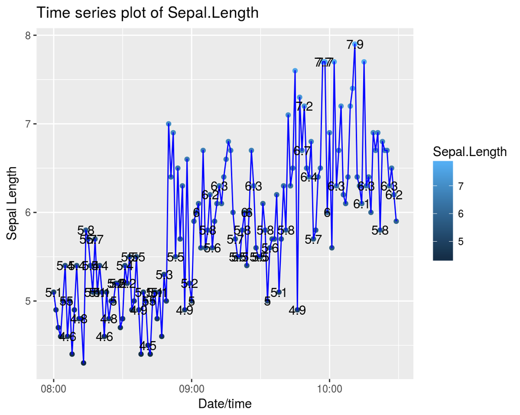

```r
iris$datetime <- seq.POSIXt(from = as.POSIXct("2012-10-10 08:00:00"), by = "1 min", length.out = nrow(iris))
iris$labels <- ifelse(iris$Sepal.Width < 2.8 | iris$Sepal.Width > 3.3, as.character(iris$Sepal.Length), "")

ggp <- ggplot(data = iris, aes(x = datetime, y = Sepal.Length)) +
  geom_point(aes(col = Sepal.Length))+
  geom_line(col = "blue") +
  ggtitle("Time series plot of Sepal.Length") +
  xlab("Date/time") + ylab("Sepal Length") +
  geom_text(aes(label = labels))
print(ggp)
```

To plot several lines in one graph:

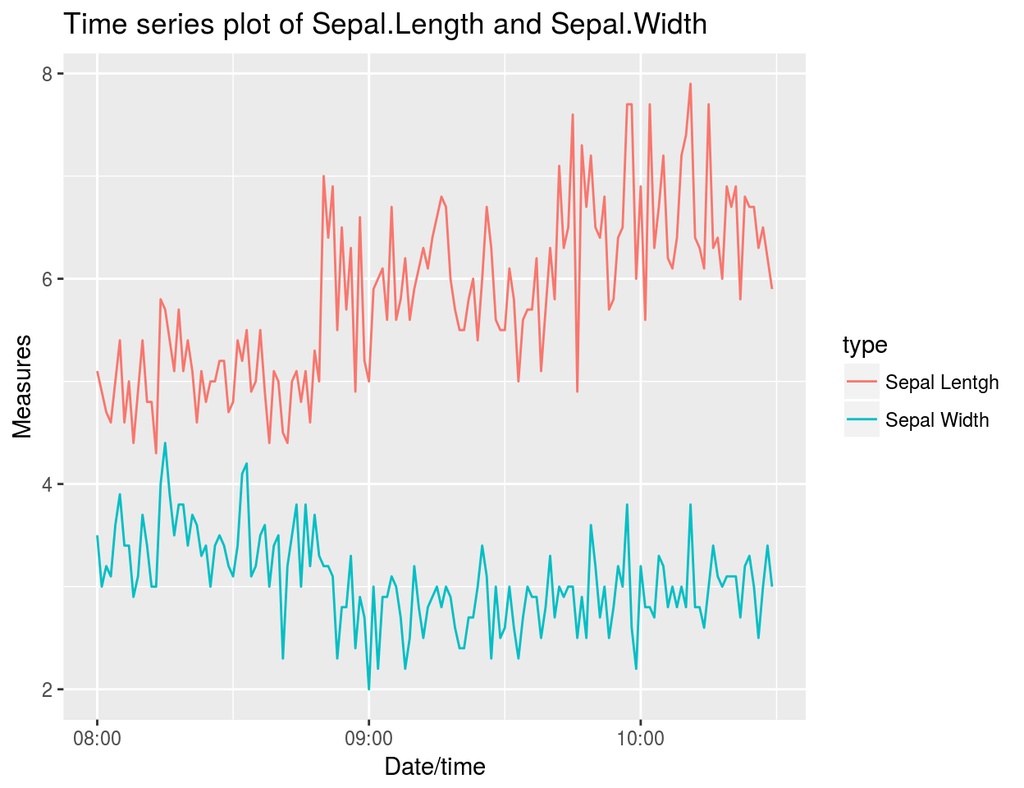

```r
dt <- data.frame(measure = c(iris$Sepal.Length,iris$Sepal.Width),
                 type = c(rep("Sepal Lentgh",150), rep("Sepal Width",150)), datetime=rep(iris$datetime,2))
ggp <- ggplot(data = dt, aes(x = datetime, y = measure, col = type)) +
  geom_line() +
  ggtitle("Time series plot of Sepal.Length and Sepal.Width") +
  xlab("Date/time") + ylab("Measures")
print(ggp)
```

or (but note the legend):

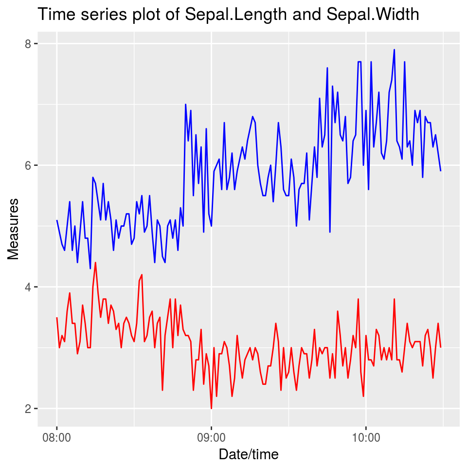

```r
ggp <- ggplot(data = iris, aes(x = datetime, y = Sepal.Length)) +
  geom_line(colour = "blue") +
  geom_line(aes(y = Sepal.Width), colour = "red") +
  ggtitle("Time series plot of Sepal.Length and Sepal.Width") +
  xlab("Date/time") + ylab("Measures")
print(ggp)
```

## Histograms

### Basic Histograms

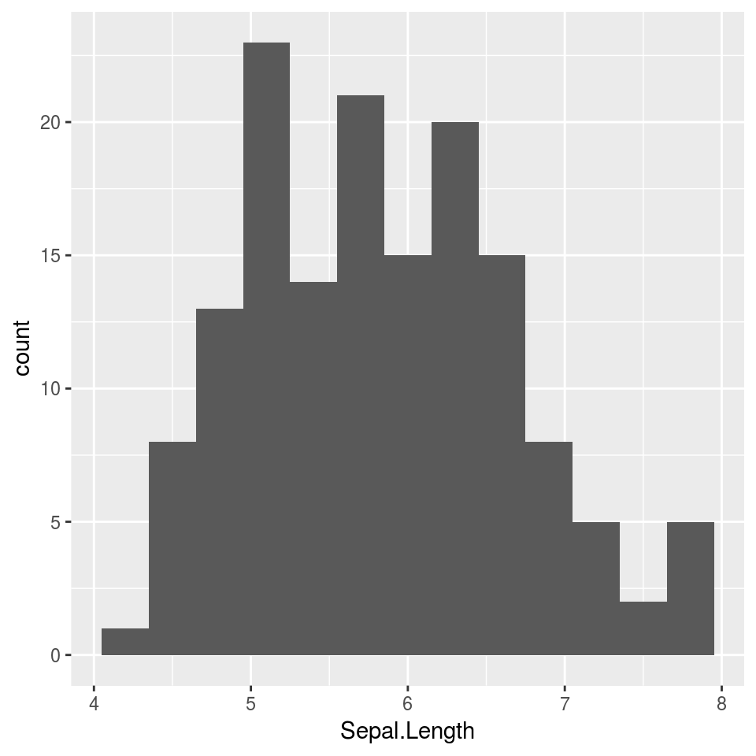

```r
(ggp <- ggplot(iris, aes(x = Sepal.Length)) + geom_histogram(binwidth = .3))
```

Draw with black outline, white fill:

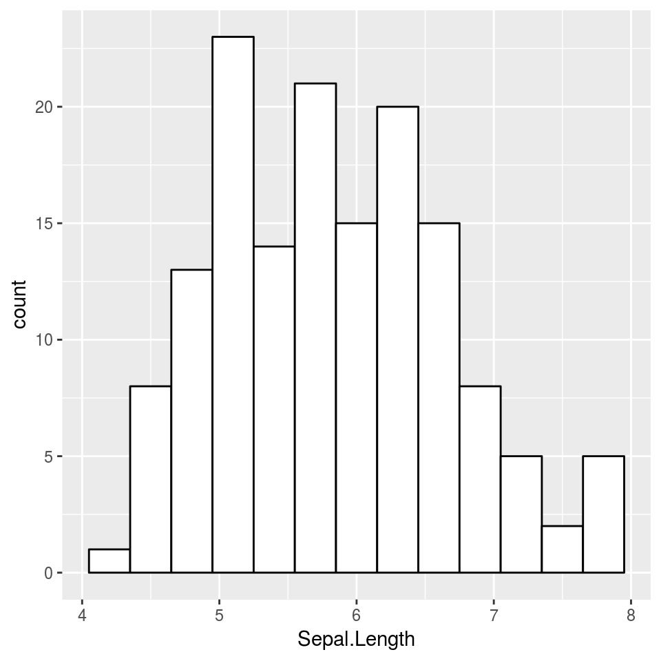

```r
(ggp <- ggplot(iris, aes(x = Sepal.Length)) +
   geom_histogram(binwidth = .3, colour = "black", fill = "white"))
```

Plot of density curve:

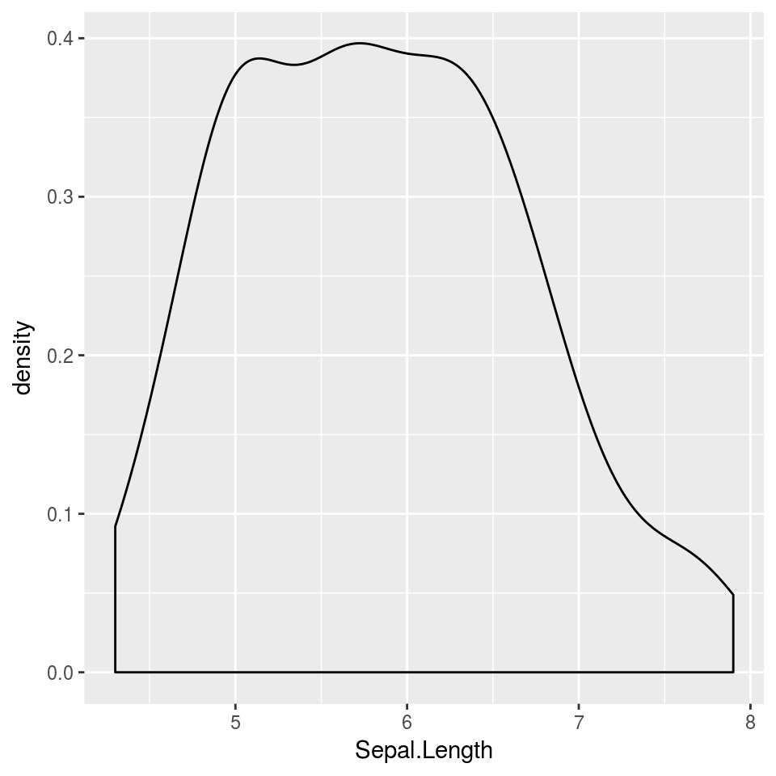

```r
(ggp <- ggplot(iris, aes(x = Sepal.Length)) + geom_density())
```

Histogram overlaid with kernel density curve:

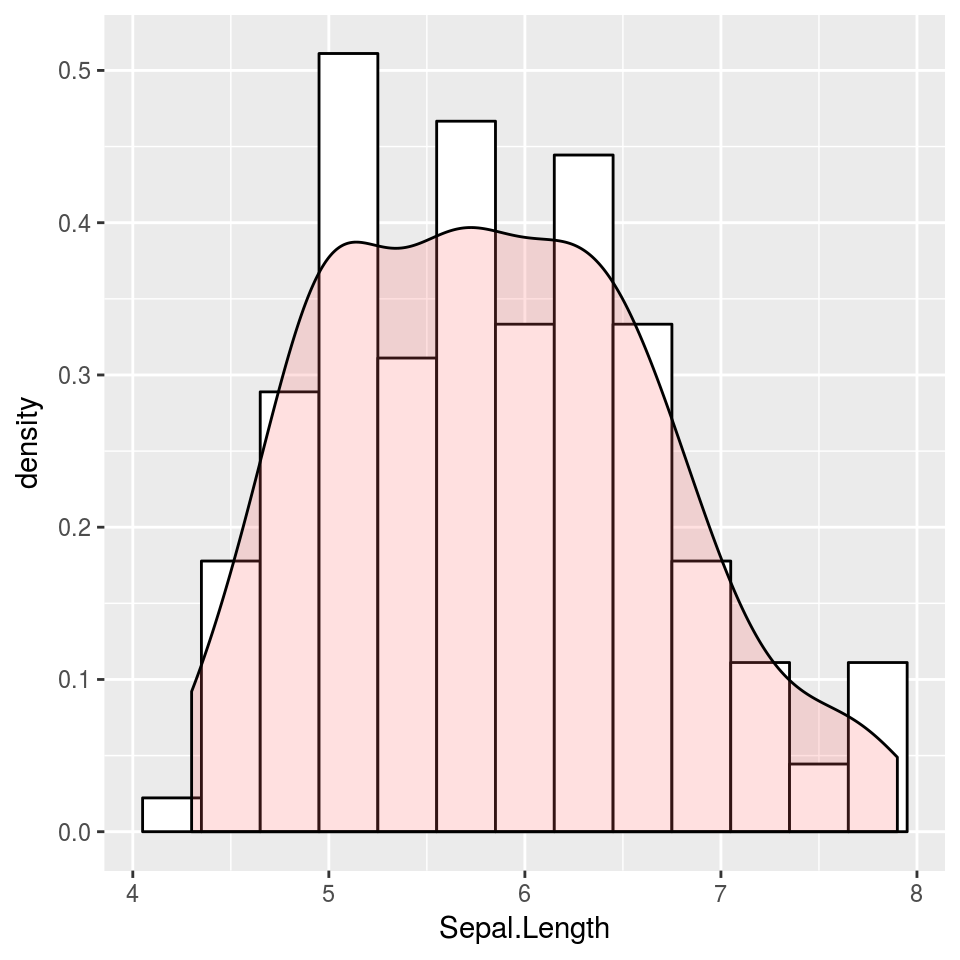

```r
ggp <- ggplot(iris, aes(x = Sepal.Length)) +
  geom_histogram(aes(y = ..density..),      # Histogram with density instead of count on y-axis
                 binwidth = .3, colour = "black", fill = "white") +
  geom_density(alpha = .2, fill = "#FF6666")  # Overlay with transparent density plot
print(ggp)
```

Histogram overlaid with kernel density curve and bars coloured with density values:

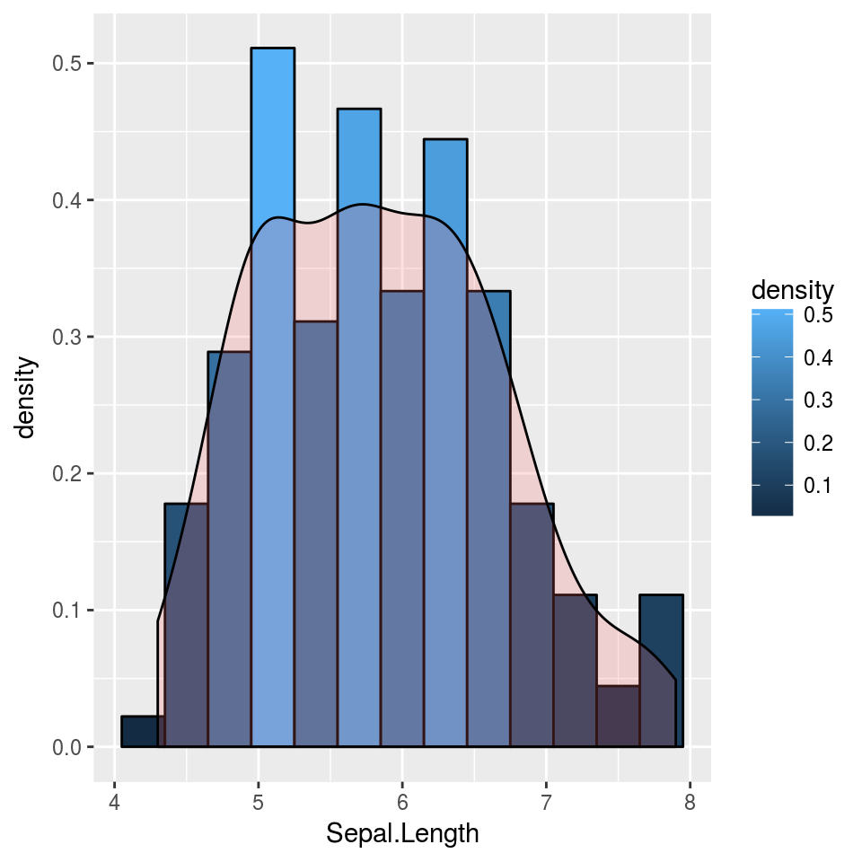

```r
ggp <- ggplot(iris, aes(x = Sepal.Length)) +
  geom_histogram(aes(y = ..density.., fill = ..density..), # Histogram with density instead of count on y-axis
                 binwidth = .3, colour = "black") +
  geom_density(alpha = .2, fill = "#FF6666")  # Overlay with transparent density plot
print(ggp)
```

Histogram with mean line:

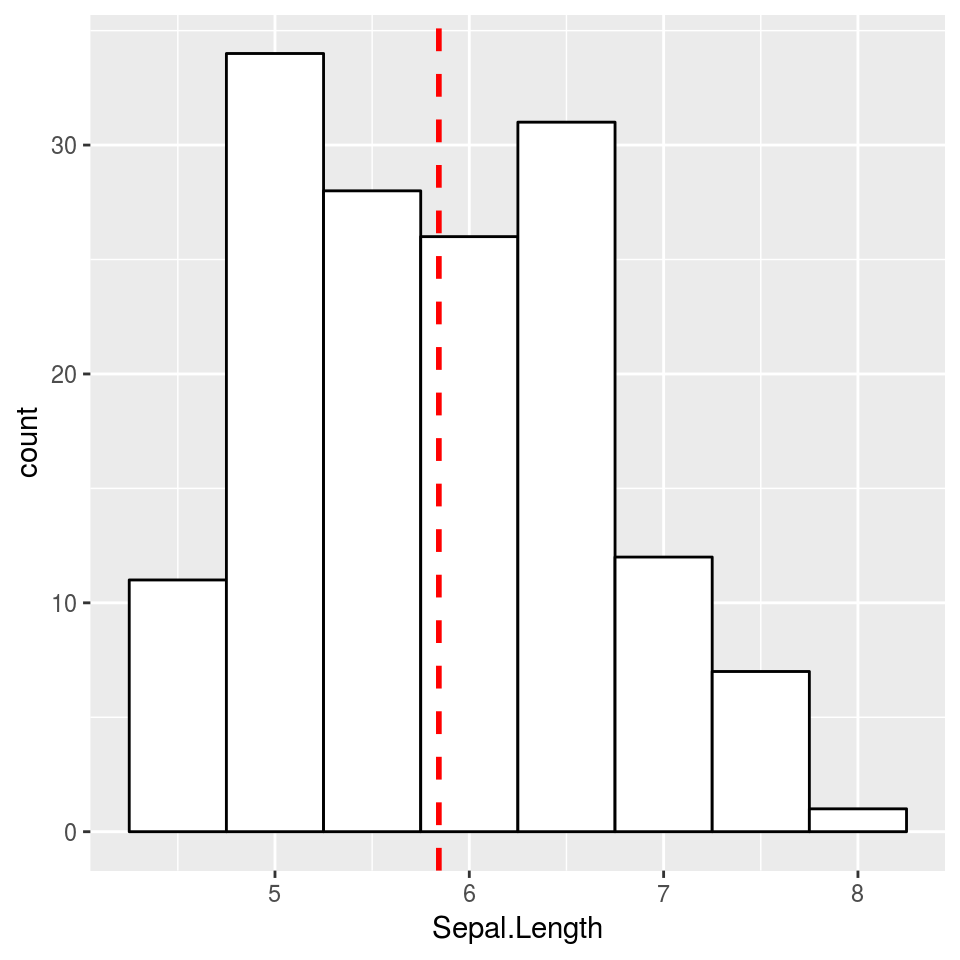

```r
ggp <- ggplot(iris, aes(x = Sepal.Length)) +
  geom_histogram(binwidth = .5, colour = "black", fill = "white") +
  geom_vline(aes(xintercept = mean(Sepal.Length, na.rm = TRUE)),   # Ignore NA values for mean
                        color = "red", linetype = "dashed", size = 1)
print(ggp)
```

Density plots with semi-transparent fill (not really univariate, but an high-impact plot):

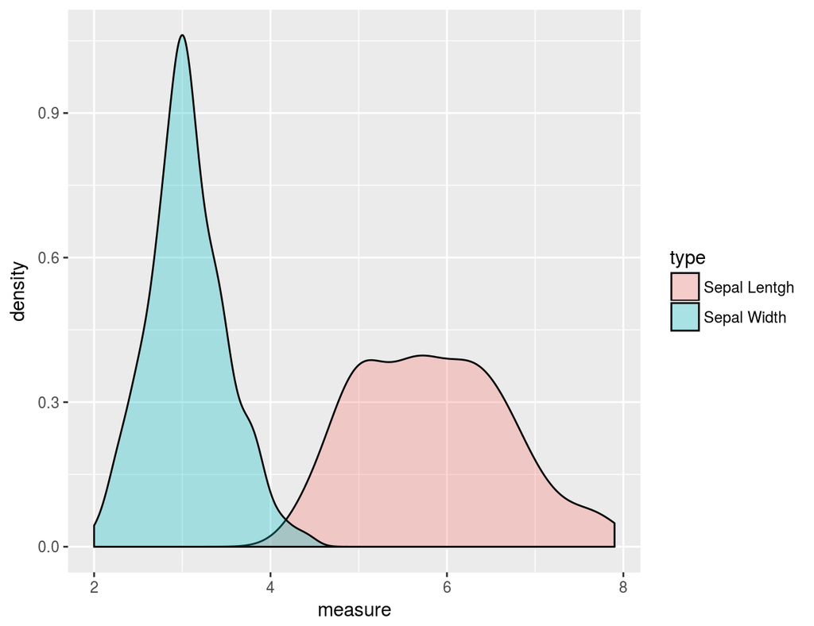

```r
(ggp <- ggplot(dt, aes(x = measure, fill = type)) + geom_density(alpha = .3))
```

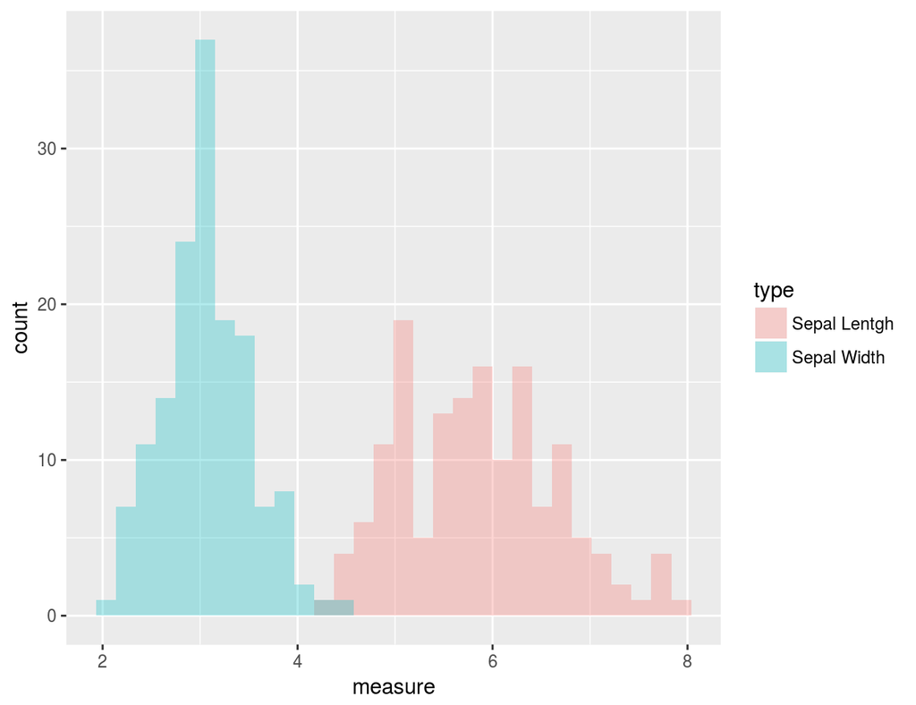

```r
(ggp <- ggplot(dt, aes(x = measure, fill = type)) + geom_histogram(alpha = 0.3, position = "identity")) # position="identity" is used to avoid stacked histograms
```

```r
rm(dt)
```

## Boxplots

Boxplots in ggplot are “mutivariate” by design. If univariate, by design ggplot requires x and y dimensions. x dimension must be put in graph, and the scale value has to be removed:

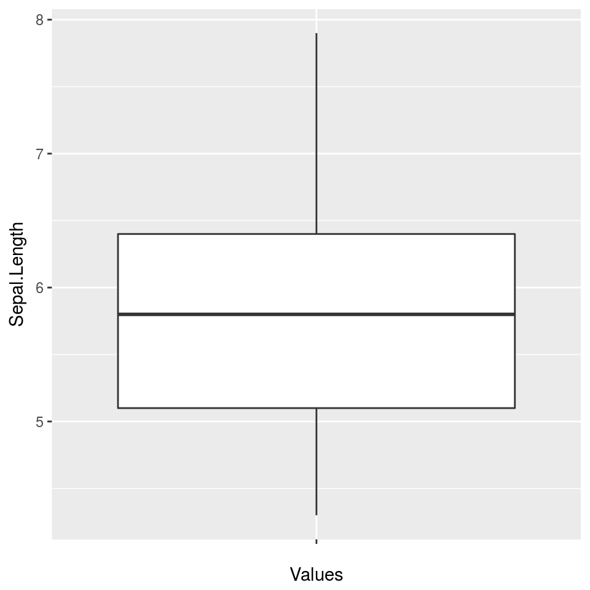

```r
ggp <- ggplot(iris, aes(x = "", y = Sepal.Length)) +
  geom_boxplot() +
  xlab("Values")
print(ggp)
```

Horizontal layout:

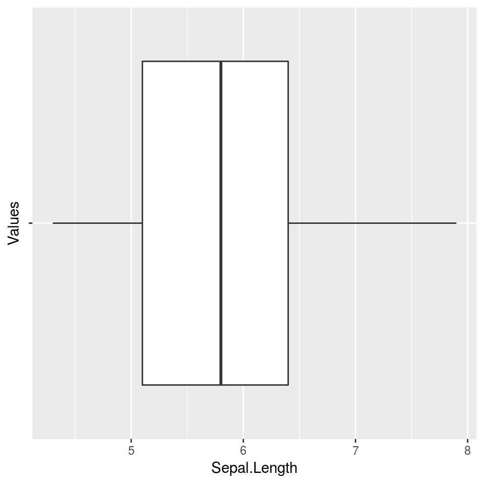

```r
(ggp <- ggp + coord_flip())  ## What happens if we use coord_flip(), e.g., with histgrams?
```

“Standard” boxplot:

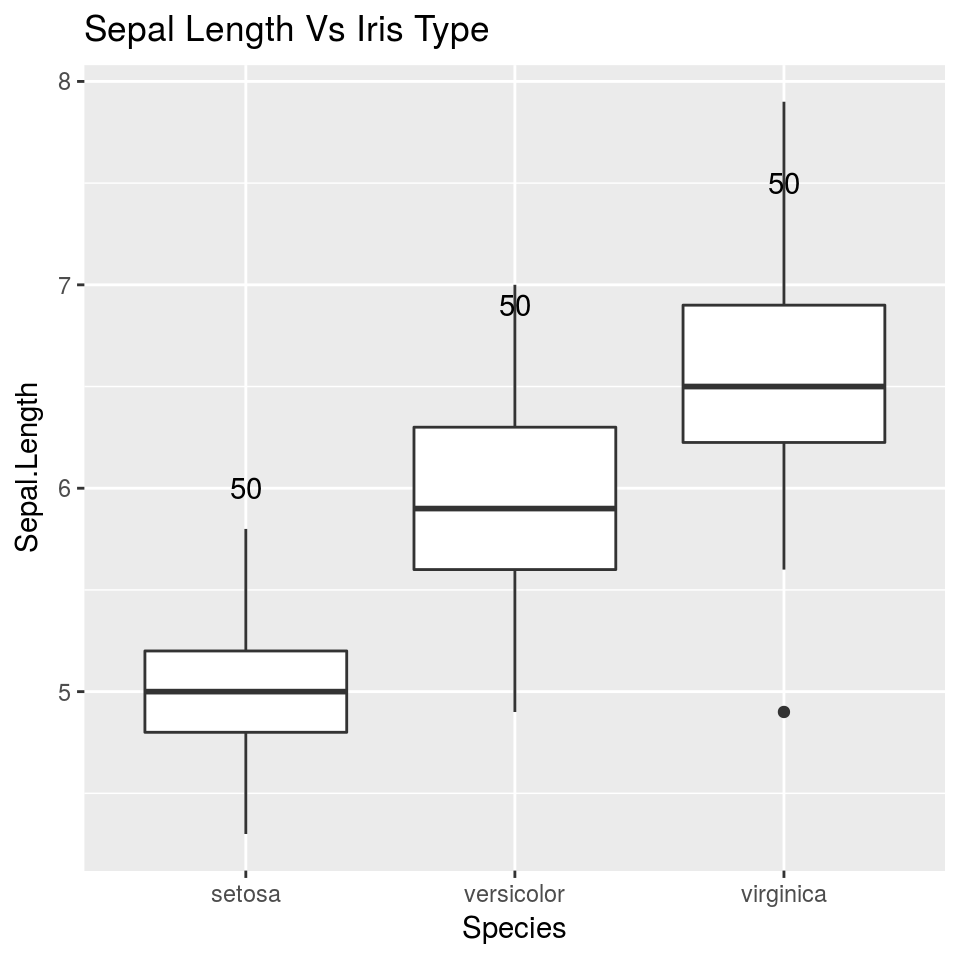

```r
nums <- tapply(iris$Sepal.Length, INDEX = iris$Species, FUN = length)
dt <- data.frame(pos = 1:length(nums), Species = names(nums), Count = nums)
ggp <- ggplot(iris, aes(x = Species, y = Sepal.Length)) +
  geom_boxplot() +
  geom_text(data=dt,aes(x = pos,
                        y = tapply(X = iris$Sepal.Length+1, INDEX = iris$Species, FUN = median),
                        label = Count)) +
  ggtitle("Sepal Length Vs Iris Type")
print(ggp)
```

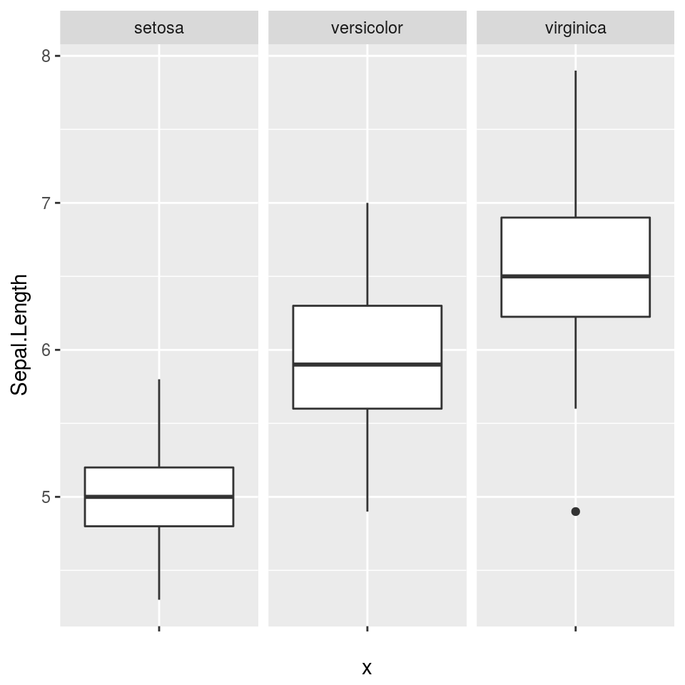

```r
ggp <- ggplot(iris, aes(x = "", y = Sepal.Length)) +
  geom_boxplot() +
  facet_grid(facets = ~Species, as.table = TRUE)
print(ggp)
```

## Violin Plots

Violin plots are similar to boxplot, but they show the distribution of variable instead of simple “summaries”. Violin plots in ggplot are “multivariate” by design too.

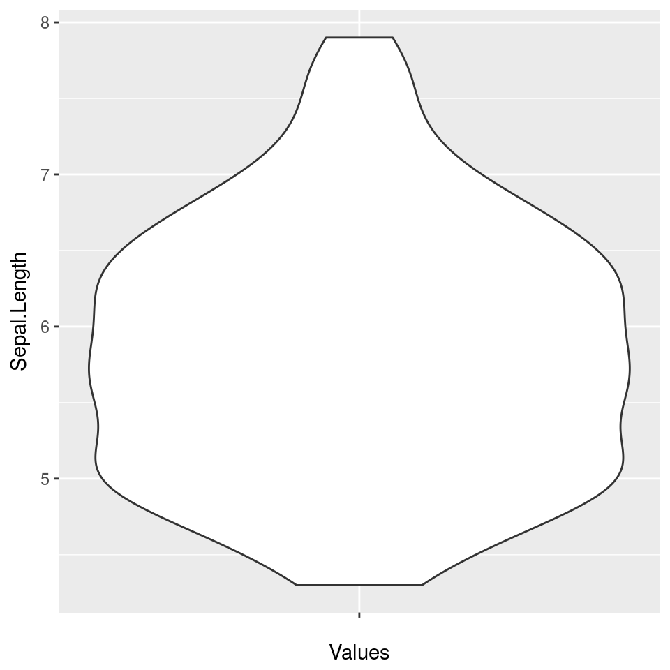

```r
ggp <- ggplot(iris, aes(x = "", y = Sepal.Length)) +
  geom_violin() +
  xlab("Values")
print(ggp)
```

Add the points to plot:

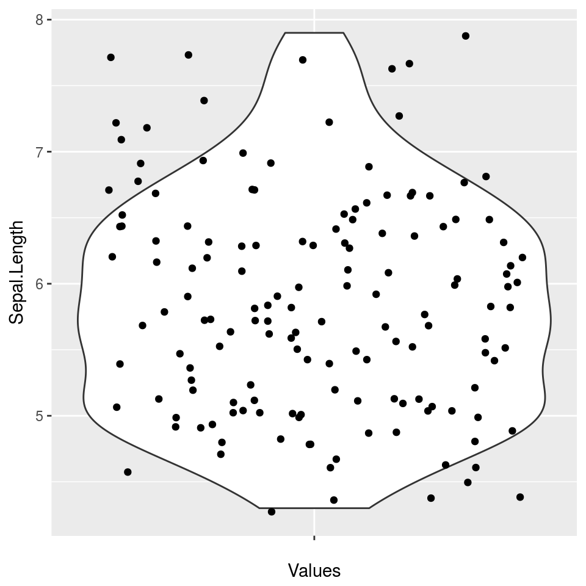

```r
ggp <- ggp + geom_jitter()
print(ggp)
```

“Standard” violin plot:

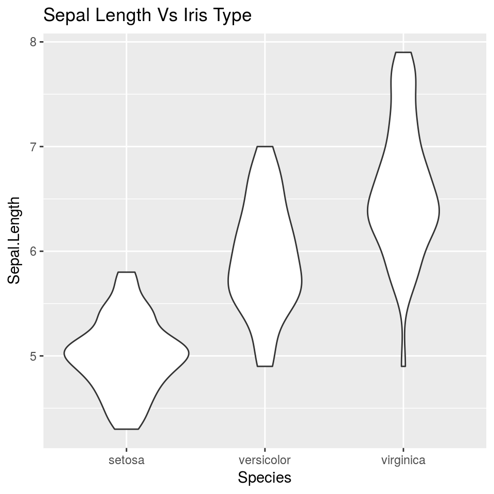

```r
ggp <- ggplot(iris, aes(x = Species, y = Sepal.Length)) +
  geom_violin() +
  ggtitle("Sepal Length Vs Iris Type")
print(ggp)
```

Overlay boxplot:

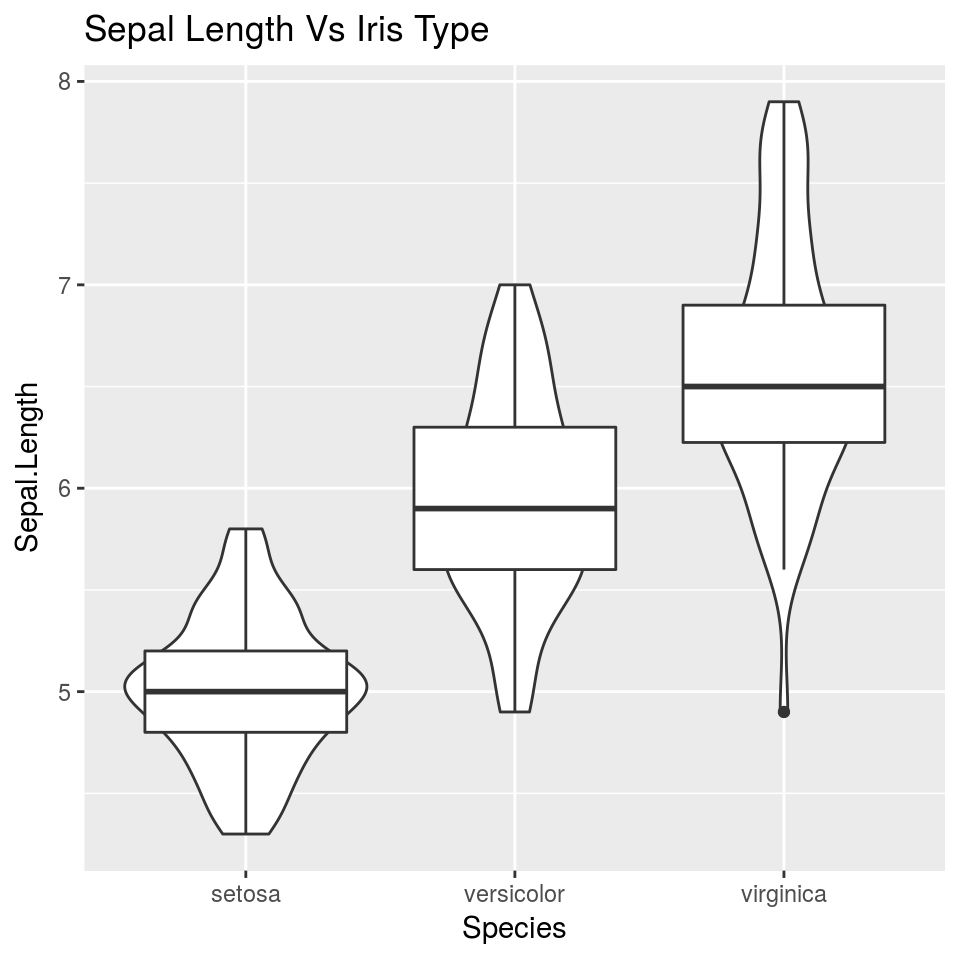

```r
ggp <- ggp + geom_boxplot()
print(ggp)
```

Add the points to plot:

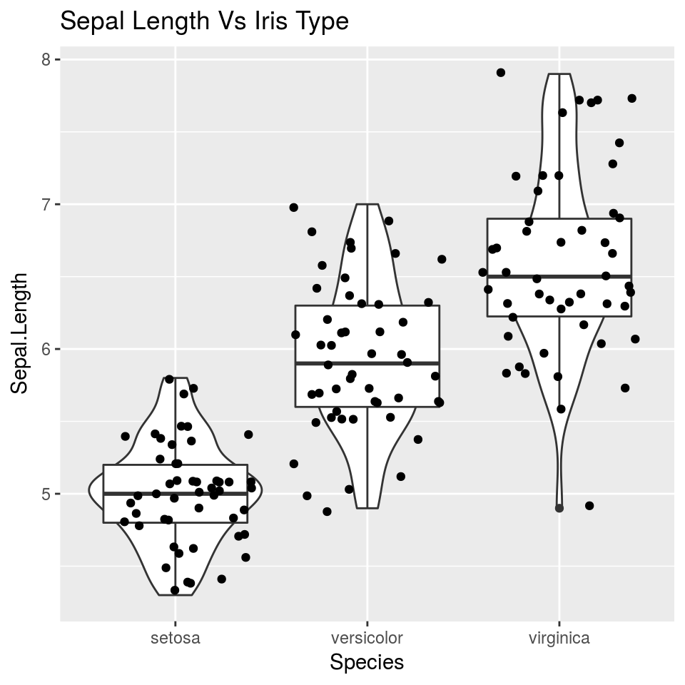

```r
ggp <- ggp + geom_jitter()
print(ggp)
```

Boxplots are also useful because they provide a simple approach to identify potential outliers.  
To show this feature of the boxplot we use the `forbes94` dataset (see the section *Introduction and datasets used* for further information).

```r
str(forbes94)
```

```
## Classes 'tbl_df', 'tbl' and 'data.frame':    800 obs. of  30 variables:
##  $ TotalComp     : int  600300 1487600 1508180 4069420 1088150 1099010 1652560 7285420 2271460 14899200 ...
##  $ WideIndustry  : Factor w/ 19 levels "Aerospacedefense",..: 1 1 1 1 1 1 1 1 1 1 ...
##  $ Company       : Factor w/ 800 levels "20th Century Industr",..: 694 103 526 448 460 319 427 322 701 321..
##  $ CEO           : Factor w/ 796 levels "Dr. Andrew S Grove",..: 777 221 453 530 383 24 128 386 327 347 ...
##  $ CityofBirth   : Factor w/ 402 levels "","Aberdeen",..: 288 35 250 94 18 76 130 281 224 97 ...
##  $ StateofBirth  : Factor w/ 51 levels "","AK","AL","AR",..: 40 15 36 7 22 37 40 21 19 24 ...
##  $ Age           : int  52 62 56 58 56 60 62 58 59 64 ...
##  $ Undergrad     : Factor w/ 262 levels "","Albion C",..: 83 186 106 124 124 67 170 196 190 198 ...
##  $ UGDegree      : Factor w/ 25 levels "","AAS","AB",..: 13 23 13 17 13 3 19 13 13 13 ...
##  $ UGDate        : int  63 54 59 57 60 55 54 57 56 52 ...
##  $ AgeOfUnder    : int  21 22 21 21 22 21 22 21 21 22 ...
##  $ Graduate      : Factor w/ 129 levels "","American Grad S",..: 22 27 39 50 50 61 72 83 86 91 ...
##  $ GradDegree    : Factor w/ 20 levels "AM","EdD","JD",..: 12 8 12 15 12 8 16 20 12 12 ...
##  $ MBA           : int  0 1 0 0 0 1 0 0 0 0 ...
```

[output cut: 16 more lines]

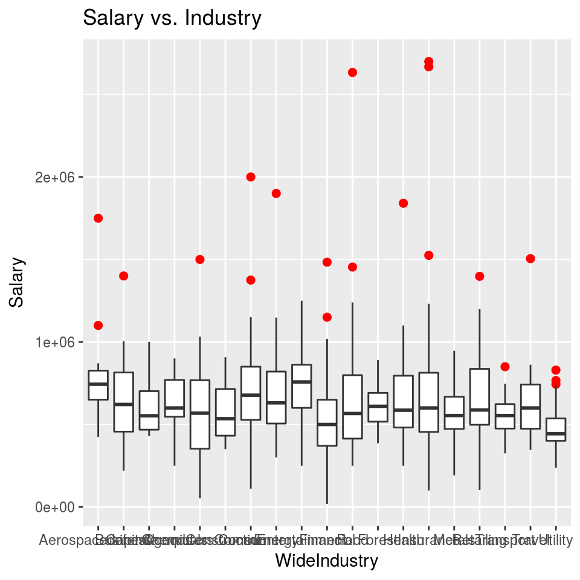

```r
ggp <- ggplot(forbes94, aes(x = WideIndustry, y = Salary)) +
  geom_boxplot(outlier.shape = 19, outlier.colour = "red", outlier.size = 2) +
  ggtitle("Salary vs. Industry")
print(ggp)
```

The boxplots above allow one to compare the salary distributions across the industries. Moreover, they clearly show that in many industries there are some outliers. These are reported in each boxplot as isolated observations. Outliers can be dangerous because they can strongly influence the results of the analysis.

## 3D Plots

If a 3D plot is desired, several options are available.  
Let’s consider the `volcano3d` dataset (see the section *Introduction and datasets used* for further information).

### Level Plots

```r
head(volcano3d)
```

```
## # A tibble: 6 x 3
##       x     y     z
##   <int> <int> <dbl>
## 1     1     1   100
## 2     2     1   101
## 3     3     1   102
## 4     4     1   103
## 5     5     1   104
## 6     6     1   105
```

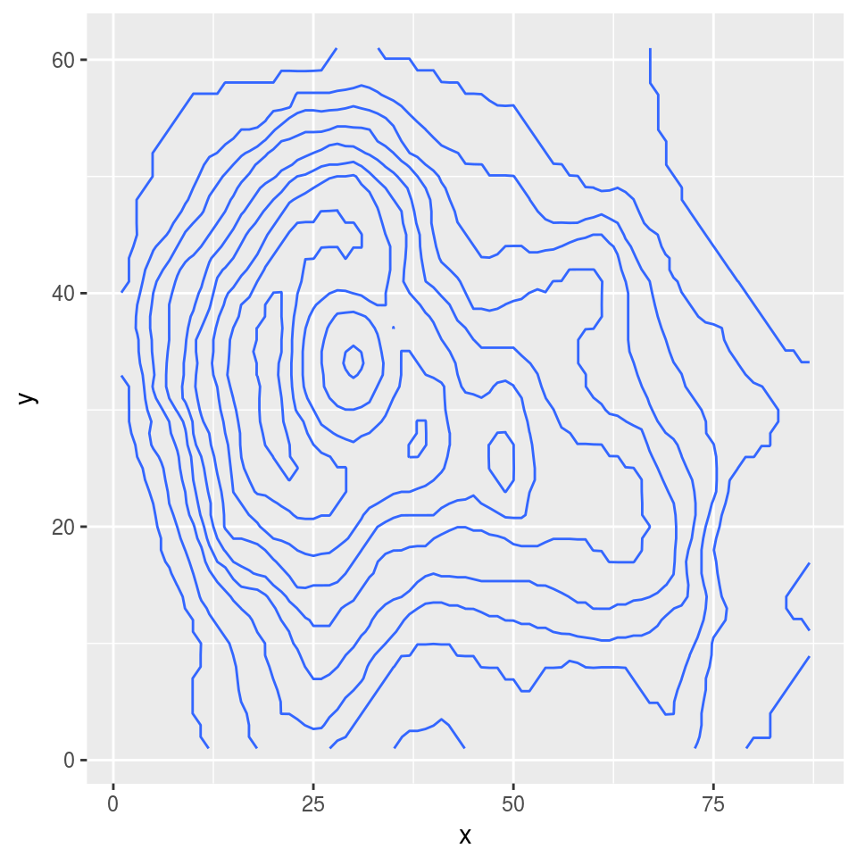

```r
ggp <- ggplot(volcano3d, aes(x = x, y = y, z = z)) +
  stat_contour()
print(ggp)
```

With coloured z levels:

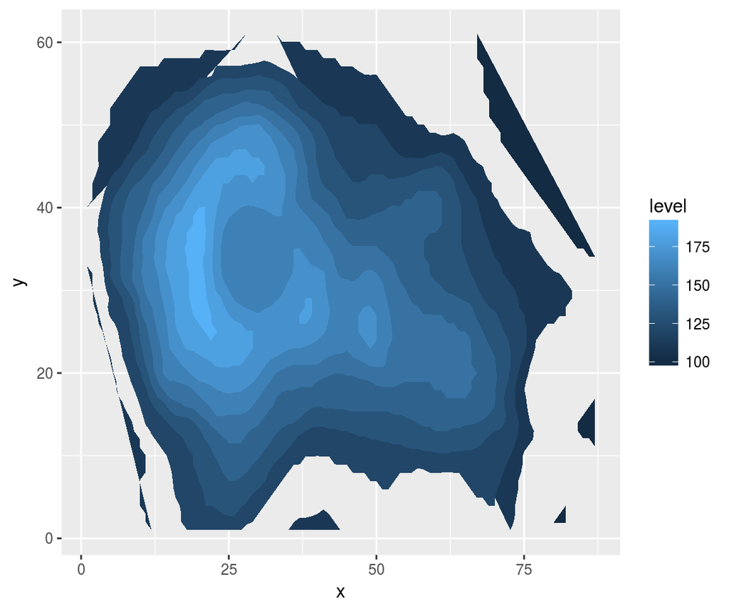

```r
ggp <- ggplot(volcano3d, aes(x = x, y = y, z = z)) +
  stat_contour(geom = "polygon", aes(fill = ..level..))
print(ggp)
```

As tiles:

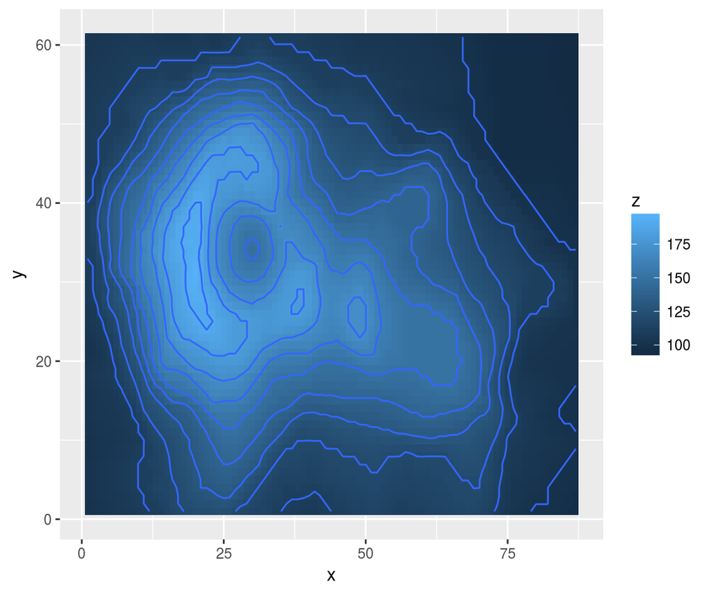

```r
ggp <- ggplot(volcano3d, aes(x = x, y = y, z = z)) +
  geom_tile(aes(fill = z)) +
  stat_contour()
print(ggp)
```

3d density plot:

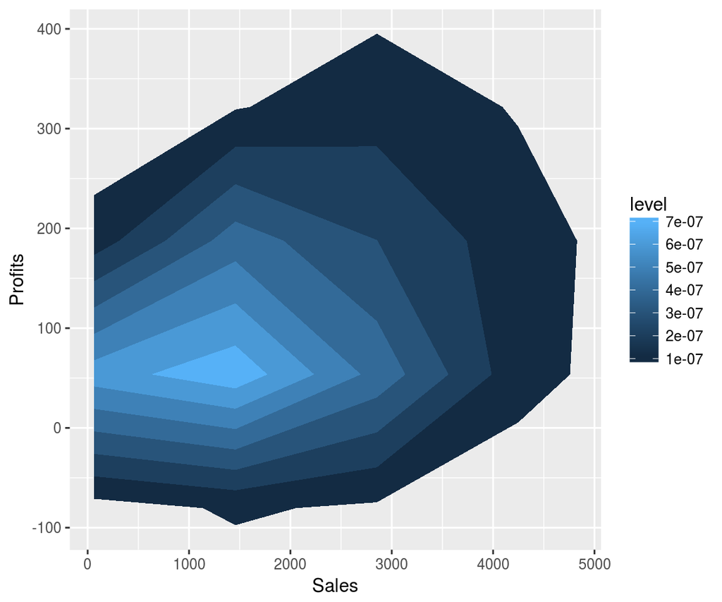

```r
ggp <- ggplot(forbes94, aes(x = Sales, y = Profits)) +
  stat_density2d(aes(fill = ..level..), geom = "polygon")
print(ggp)
```

### 3D Scatterplots

Try these examples directly in your `R`, since no plots will be shown (these plots are interactive and you can move and turn them by clicking on them with the mouse).

```r
require(rgl)
```

```r
open3d()
with(forbes94,
plot3d(x = StockOwned, y = Sales, z = Profits,
       xlab = "StockOwned", ylab = "Sales", zlab = "Profits", type = "p"#), #col=,
#        size, lwd, radius,
#        add = FALSE, aspect = !add, ...)
))
```

```r
open3d()
with(forbes94,
     plot3d(x = log(StockOwned), y = log(Sales), z = Profits,
            xlab = "StockOwned", ylab = "Sales", zlab = "Profits", type = "s",
            col = as.numeric(as.factor(WideIndustry))
            #        size, lwd, radius,
            #        add = FALSE, aspect = !add, ...)
     ))
```

```r
open3d()
with(forbes94,
     plot3d(x = log(StockOwned), y = log(Sales), z = Profits,
            xlab = "StockOwned", ylab = "Sales", zlab = "Profits", type = "p",
            col = as.numeric(as.factor(WideIndustry))
            #        size, lwd, radius,
            #        add = FALSE, aspect = !add, ...)
     ))
```

### 3D Surfaces

```r
z <- 2 * volcano        # Exaggerate the relief
x <- 10 * (1:nrow(z))   # 10 meter spacing (S to N)
y <- 10 * (1:ncol(z))   # 10 meter spacing (E to W)
zlim <- range(z)
zlen <- zlim[2] - zlim[1] + 1
colorlut <- terrain.colors(zlen) # height color lookup table
col <- colorlut[ z - zlim[1] + 1 ] # assign colors to heights for each point
open3d()
surface3d(x, y, z, color = col, back = "lines")
```